# Filtrado_TFM_Bifidobacterium_Humano

Antonio Bahilo

22/01/2023

## Script en *Bash* para la descarga y lanzamiento del programa FastANI

```
#Programa para separar genomas descargados por "Host Group" en un único file multifasta.
##Si se desea lanzar desde un file recodaras poner en la primera linea del programa(#!/bin/bash)

#Paso 1: Eliminar el carácter "|" y "\t" de los nombres de los archivos fasta y Separamos los genomas según el nombre del fasta que empieza cada linea por ">"

#Cambiar el PNH por el nombre que se haya descargado

sed -e 's/|/+/g' -e 's/ /_/g' BVBRC_genome_sequence_PNH.fasta > BVBRC_genome_sequence_PNH_clean.fasta
cd Genome_PNH/
cat ../BVBRC_genome_sequence_PNH_clean.fasta | awk '{ if (substr($0, 1, 1)==">") {filename=(substr($0,2) ".fasta")} ;print $0 >> filename; close(filename)}'

#Otra forma de cambiar los nombres de los files
#rename  's/ /_/g' *.fasta
#rename  's/|/X/g' *.fasta

#Paso 2: Editamos los nombres de los archivos dejando solo el "Genome ID"  y ponemos todos las secuencias fasta organizadas por organismos
cd Genome_PNH/
a=.fasta
for i in $(ls);do name="$(echo $i | awk -F "+" '{print $3}' | sed -e 's/_//' -e 's/].fasta$//')"; Newname=$name$a; cat $i >> "$Newname"; rm $i; done


#Paso 3: Generar lista con nombre genomas en fna, mas rápido.
cd ../
a=Genome_PNH/
for i in $(cd Genome_PNH;ls)
do
  echo "$a$i" >> genome_list_PNH.txt
done

#Paso 4: Lanzar el programa FastANI
##Programa FastANI
##Significado de los comandos: --ql[es la lista con los genomas a analizar]--rl[es la lista con los genomas de referencia] -t [Nº de procesador a utilizar] -o[nombre de file de salida] --fragLen[tamaño de los fragmentos a comparar]
# Cambiar el archivo ql y rl por el nombre usado, en el caso anterior sería: genome_list_PNH.txt
time fastani --ql genome_list.txt --rl genome_list.txt -t 4 -o bifido_out --fragLen 1000 --matrix # Para Humano

time fastani --ql genome_list_cow1.txt --rl genome_list_cow1.txt -t 4 -o bifido_out_cow --fragLen 1000 --matrix #Para la vaca
time fastani --ql genome_list_pig.txt --rl genome_list_pig.txt -t 4 -o bifido_out_pig --fragLen 1000 --matrix #Para el cerdo
time fastani --ql genome_list_PNH.txt --rl genome_list_PNH.txt -t 4 -o bifido_out_PNH --fragLen 1000 --matrix #Para los primates no humanos
```

## Filtrado ANI Humano con R

A continuación, se muestran los pasos para filtrar las muestras de las diferentes especies de *Bifidobacterium spp* a partir de las secuencias completas de bacterias extraidas del humano.

```r
BVBRC_genome <- read.delim("/Users/toni/Desktop/TFM_BioInfo/files/BVBRC_genome.txt", quote="")
bifido_out <- read.delim("/Users/toni/Desktop/TFM_BioInfo/files/bifido_out_822", header=FALSE)
```

## Cargamos librerias

```r
library("reshape2")
#library("ComplexHeatmap")
library(ggplot2)
library("gplots")
library(dplyr)
library("vioplot")
```

## Generamos Matriz

Cargamos los datos obtenidos por el programa FastANI y los pasamos a una matriz

```r
x <- bifido_out #Generamos una variable con los datos
pre_matrix <- acast(x, V1~V2, value.var="V3")# Creamos la matriz de los datos
pre_matrix[is.na(pre_matrix)] <- 70 #Los datos con NA los pasamos a 70
```

## Poner nombre especies en las columnas

```r
matrix<- pre_matrix
count=0
for (i in colnames(matrix)) {
  count=count+1
  NewName<-substring(i,first = 12, last = nchar(i)-4 )#quitamos los 12 primeros caracteres "genome_fna/" y los ultimos 4 ".fna"
  colnames(matrix)[count]<-c(NewName)
  for (i in 1:nrow(BVBRC_genome)) {
    z<-substring(BVBRC_genome$Genome.ID[i],first = 2, last = nchar(BVBRC_genome$Genome.ID[i])-1 )

    if (colnames(matrix)[count] == z ){
      colnames(matrix)[count]<-c(BVBRC_genome$Genome.Name[i])
      row.names(matrix)[count]<-c(BVBRC_genome$Genome.Name[i])
    }
  }
}
```

## Generar otra matriz pero con los ID

```r
matrix_ID<- pre_matrix
count=0
for (i in colnames(matrix_ID)) {
  count=count+1
  NewName<-substring(i,first = 12, last = nchar(i)-4 )#quitamos los 12 primeros caracteres "genome_fna/" y los ultimos 4 ".fna"
  colnames(matrix_ID)[count]<-c(NewName)
  row.names(matrix_ID)[count]<-c(NewName)
}
```

## Eliminar Col y filas de especeis y géneros no vinculados a Bifido

Genero bucle para saber cuantas especies o géneros tengo que eliminar. Importante en caso de usa otra especie que no sea la Humana cambiar las especies de Bifido.

```r
count=0
for (i in 1:nrow(matrix)) {
  z<-row.names(matrix)[i]
  name<- strsplit(z," ")
  gg<- name[[1]][1]#Cogemos el genero
  sp<- name[[1]][2]#Cogemos la especie
  if ((z =="genome_fna/Lacto_324831.13.fna") || (z=="genome_fna/Escherichia_coli_str_K12_MG1655.fna")){
    count=count+1
  }
  if ((!is.na(gg)) &((gg =="\"Enterococcus") || (gg=="\"Cutibacterium"))){
    count=count+1
  }
  if ((!is.na(sp)) &((sp =="scardovii") || (sp=="gallicum") || (sp=="thermophilum"))){
    count=count+1
  }
}
```

Ahora genermos un bucle para que elimine todas las especies o géneros que no tienen nada que ver con bifido

```r
lon=(nrow(matrix)-count)#Extraemos la longitud de la matriz sin las especie arriba eliminadas("count")

while(nrow(matrix) > (lon)){

  for (i in 1:nrow(matrix)) {
    z<-row.names(matrix)[i]
    name<- strsplit(z," ")
    gg<- name[[1]][1]#Cogemos el genero
    sp<- name[[1]][2]#Cogemos la especie
    if ((!is.na(z)) & ((z =="genome_fna/Lacto_324831.13.fna") || (z=="genome_fna/Escherichia_coli_str_K12_MG1655.fna"))){
      matrix<- matrix[c(-i),]#Eliminamos la fila
    }
    if ((!is.na(gg)) & ((gg =="\"Enterococcus") || (gg=="\"Cutibacterium"))){
      matrix<- matrix[c(-i),]
    }
    if ((!is.na(sp)) &((sp =="scardovii") || (sp=="gallicum") || (sp=="thermophilum"))){
      matrix<- matrix[c(-i),]
    }
  }
  for (i in 1:ncol(matrix)) { #Hacemos lo mismo pero para eliminar columnas
    z<-colnames(matrix)[i]
    name<- strsplit(z," ")
    gg<- name[[1]][1]#Cogemos el genero
    sp<- name[[1]][2]#Cogemos la especie
    if ((!is.na(z)) & ((z =="Lacto_324831.13") || (z=="Escherichia_coli_str_K12_MG1655"))){#Aquí es diferente el nombre de las filas
      matrix<- matrix[,c(-i)]#Eliminamos la columna
    }
    if ((!is.na(gg)) & ((gg =="\"Enterococcus") || (gg=="\"Cutibacterium"))){
      matrix<- matrix[,c(-i)]
    }
    if ((!is.na(sp)) &((sp =="scardovii") || (sp=="gallicum") || (sp=="thermophilum"))){
      matrix<- matrix[,c(-i)]
    }
  }
}
```

## Asignar especies NO descritas

Asignamos las especies que no estan descritas a las especies que tengan mayor similitud de ANI. Generamos una función que recorra cada posición de la columna y busque el mayor valor de ANI.

```r
funn <- function(matr,posfila) {
  f_count=90
  nann=c("tt")
  final<-c("se asgina a")
  for(y in 1:ncol(matr)){
    z<-colnames(matrix)[y]
    name<- strsplit(z," ")

    sp<- name[[1]][2]#Cogemos la especie
    count<-matr[posfila,y]
    if ((sp !="sp.")&(count>f_count)){
      f_count<-matr[posfila,y]
      nann<- replace(nann,1,z)
    }
  }
  final<-append(final,c(nann,f_count))
}
```

Cambiamos las especies detectadas *B.sp* por su especie con mayor ANI

```r
top<-c()
cambio=3
for(i in 1:nrow(matrix)){
  b<-row.names(matrix)[i]
  name<- strsplit(b," ")
  sp<- name[[1]][2]#Cogemos la especie
  if (sp =="sp."){

    a<- funn(matrix,i)#si queires saber todas las especies que se cambairan de sp. y los ANI
    top<- append(top,c(b,a))
    row.names(matrix)[i]<-paste(top[cambio],"Antes sp.",sep = "_")
    colnames(matrix)[i]<-paste(top[cambio],"Antes sp.",sep = "_")
    cambio<-cambio+4
  }
}

#Esto es un ejemplo de los cambios generados de la especie sp. por el resto
print(top[1:3])
```

```
## [1] "\"Bifidobacterium sp. N4G05\""
## [2] "se asgina a"
## [3] "\"Bifidobacterium kashiwanohense PV20-2\""
```

## Reasignar especies

Para unificar especies, antes se deben obtener las distribuciones de ANI intra-especie,es decir, para cada especie analizada se deben rescatar todos los ANIs resultantes de las comparaciones entre sus cepas. Así obtendrás medias, medianas y desviaciones (además IQR o CI95%) para cada especie.

```r
#Volvemos a observar que ya solo tenemos las especies que nos interesan
lista_especies=c()
lista_generos=c()
lista_posicion_especie=c()# Guardamos la lista con las posiciones encontradas para utilizarla después
count=0
for (i in colnames(matrix)) {
  count=count+1
  name<- strsplit(i," ")

  yy<- name[[1]][1]#Cogemos el genero
  xx<- name[[1]][2]#Cogemos la especie
  if (!(yy %in% lista_generos)){
    lista_generos<- append(lista_generos,yy)
  }
  if ((yy== "\"Bifidobacterium") & (!(xx %in% lista_especies))){
    lista_especies<- append(lista_especies,xx)
    lista_posicion_especie<- append(lista_posicion_especie,count)
  }
}

print(lista_especies)
```

```
##  [1] "breve"             "kashiwanohense"    "animalis"
##  [4] "bifidum"           "adolescentis"      "longum"
##  [7] "pseudocatenulatum" "pseudolongum"      "angulatum"
## [10] "catenulatum"       "dentium"           "stercoris"
```

```r
print(lista_generos)
```

```
## [1] "\"Bifidobacterium"
```

## Comparaciones estadísticas

### PASO 1.1:

Primero obtenemos las distribuciones de ANI INTRA-especie y con ello vemos el intervalo de confianza para cada especie

GENERAMOS LA MATRIZ donde rellenar los valores estadísticos obtenidos de cada especie

```r
col_especies<- lista_especies
filas_stats<-c("Tamaño_N","Media_ANI_intra","Desviación","CI 95%","Mínimo")
matriz_stat_intra<-matrix(0,ncol = length(col_especies),nrow=length(filas_stats))
colnames(matriz_stat_intra)<-col_especies;rownames(matriz_stat_intra)<- filas_stats
matriz_stat_inter<-matriz_stat_intra
row.names(matriz_stat_inter)[2]<-"media_ANI_inter"
#Creamos una función que analizará CI 95%.
CI_z <- function (x, ci = 0.95)#calculamos con z-tablas porque conocemos la desviación y n>30
{
  standard_deviation <- sd(x)
  sample_size <- length(x)
  Margin_Error <- abs(qnorm((1-ci)/2))* standard_deviation/sqrt(sample_size)
  df_out <- data.frame( sample_size=length(x), Mean=mean(x), sd=sd(x),
                        Margin_Error=Margin_Error,
                        CI_inferior=(mean(x) - Margin_Error),
                        CI_superior=(mean(x) + Margin_Error),
                        Min=min(x))
  return(df_out)
}
```

Generamos el bucle para rellenar la matriz. Además, obtenemos las gráficas donde se pueden observar la distribución de los ANI para cada especie lo que permite visualmente observar si hay algún organismo que no forma parte de ese mismo grupo de especie.

```
## [1] "breve"
```

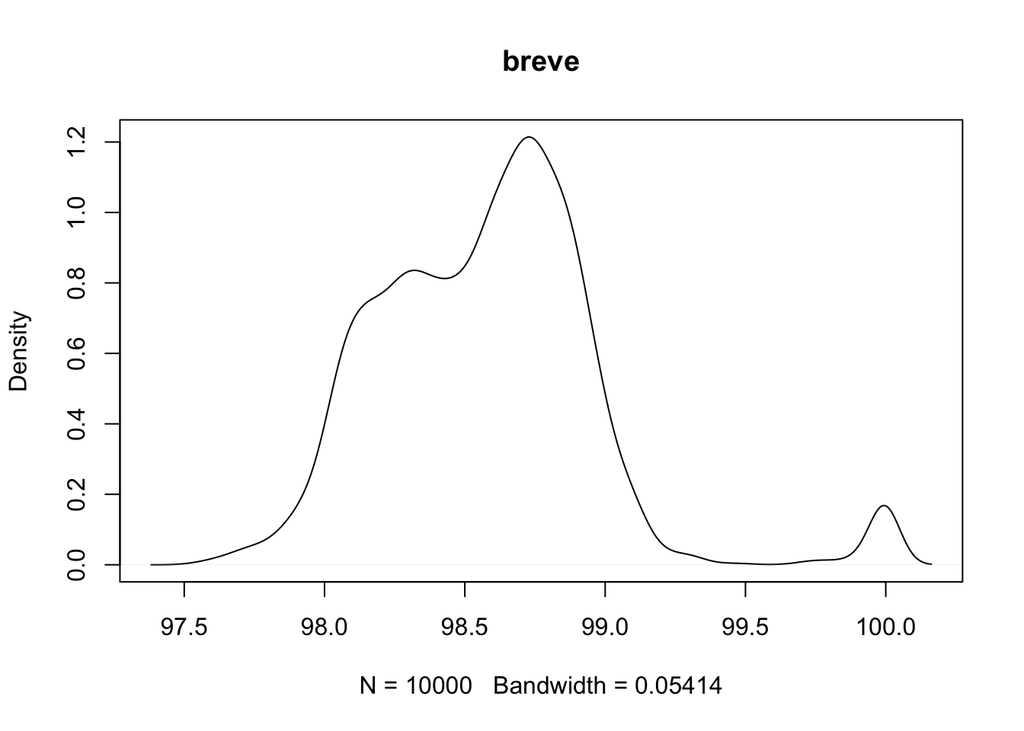

```
## [1] "kashiwanohense"
```

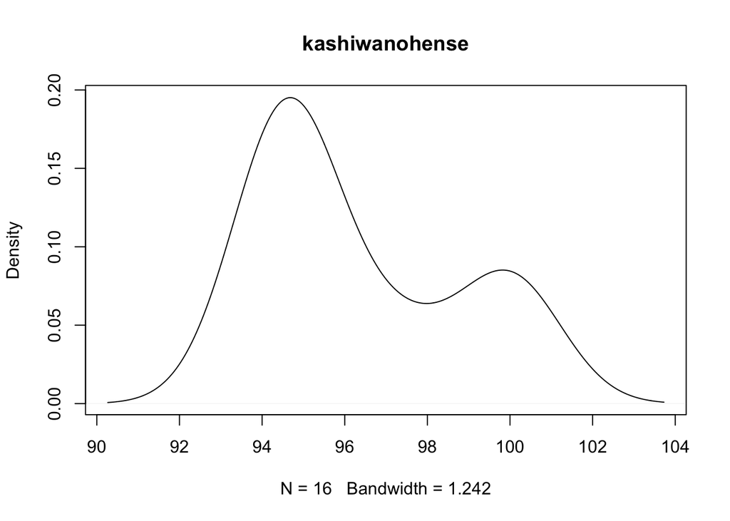

```
## [1] "animalis"
```

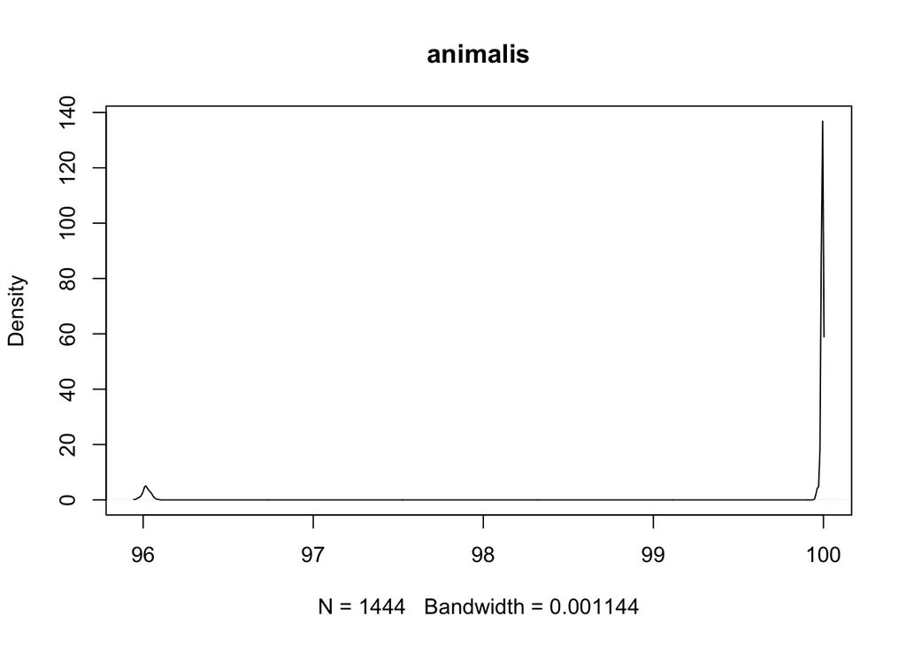

```
## [1] "bifidum"
```

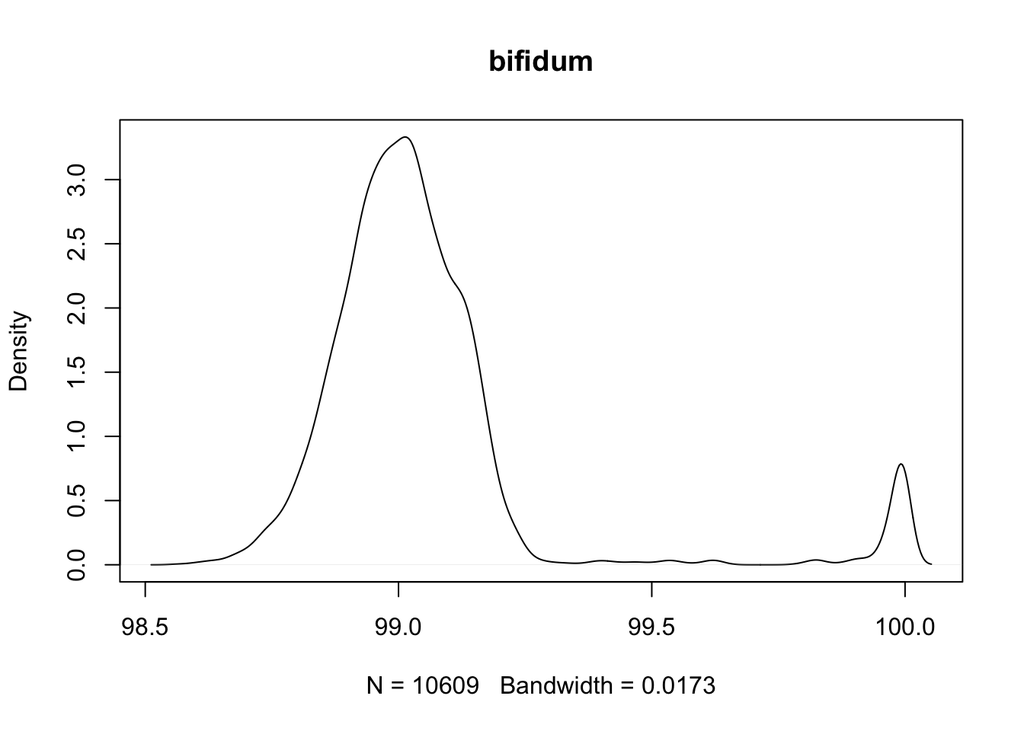

```
## [1] "adolescentis"
```

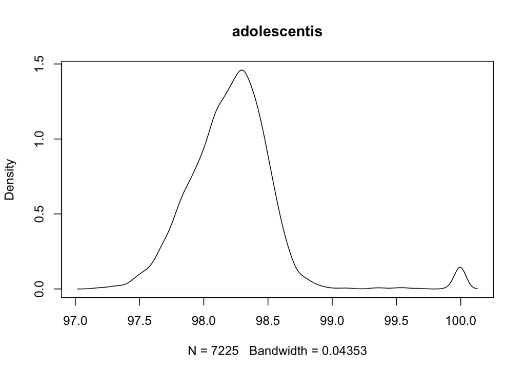

```
## [1] "longum"
```

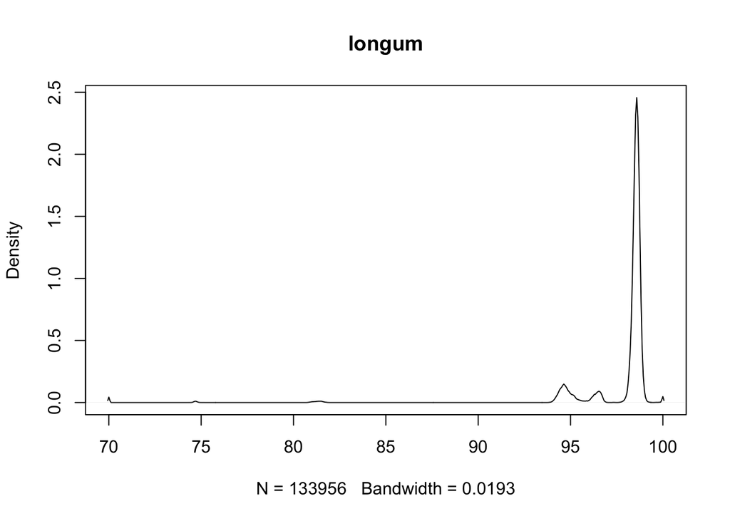

```
## [1] "pseudocatenulatum"
```

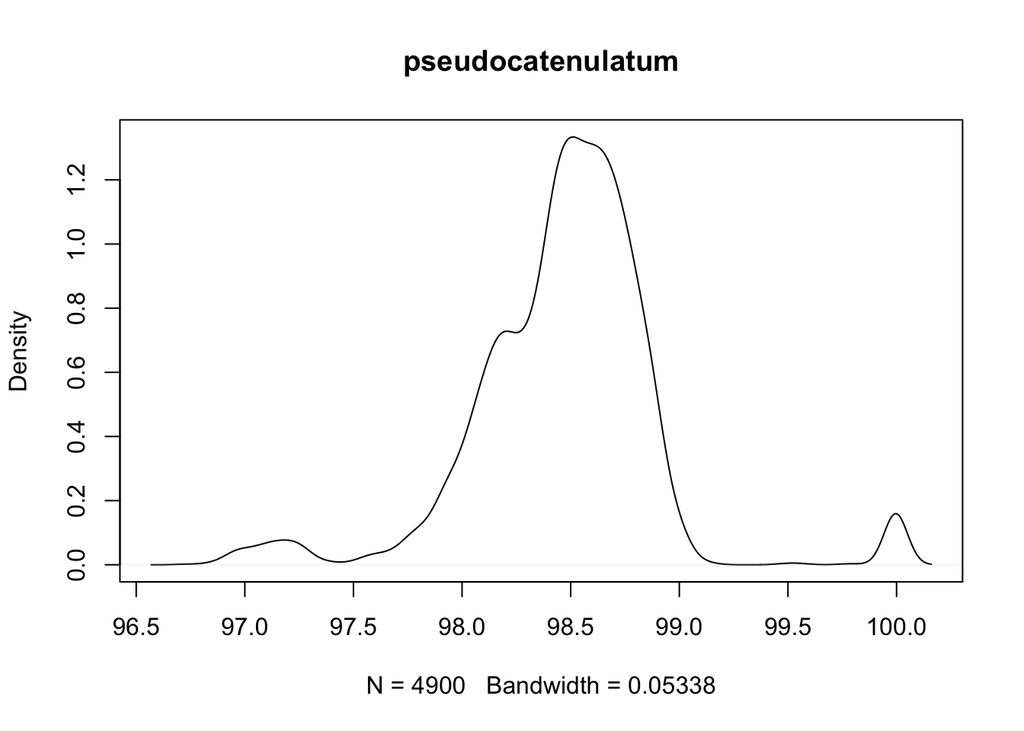

```
## [1] "pseudolongum"
```

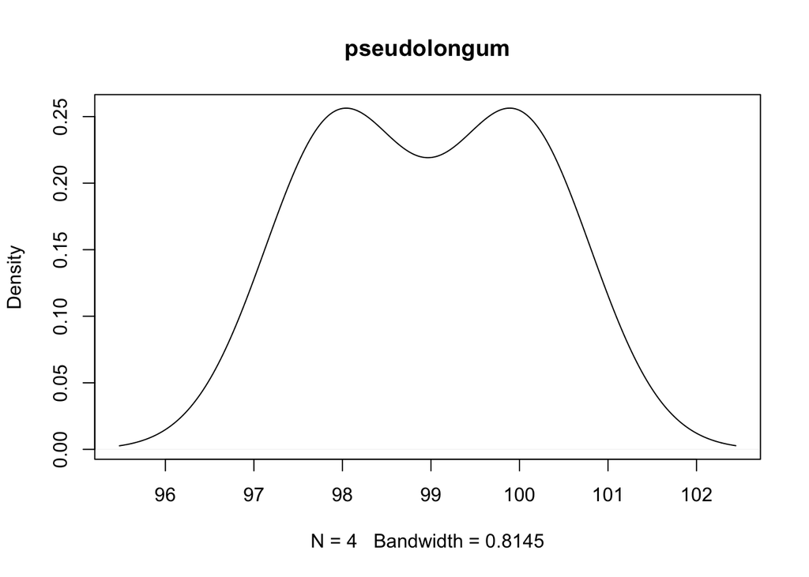

```
## [1] "angulatum"
```

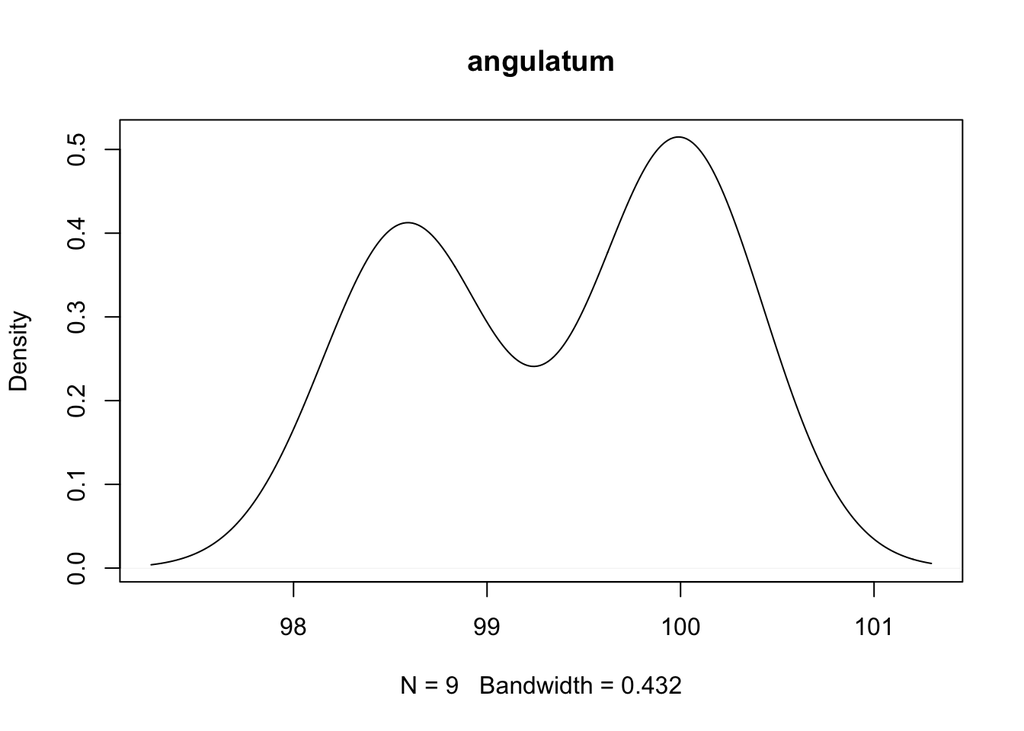

```
## [1] "catenulatum"
```

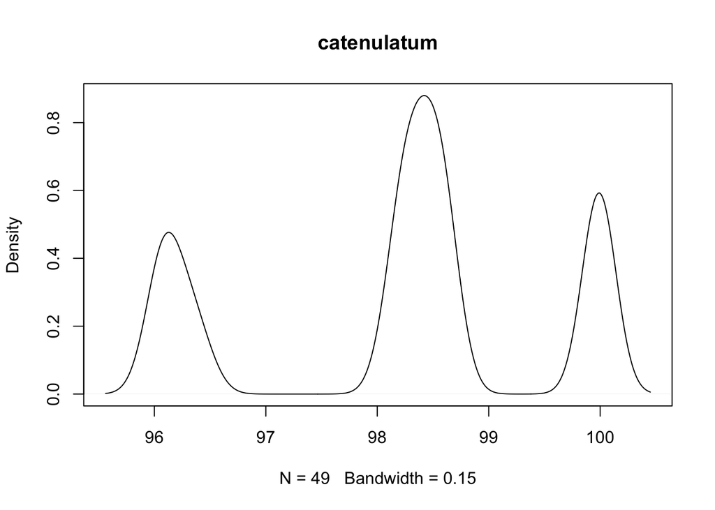

```
## [1] "dentium"
```

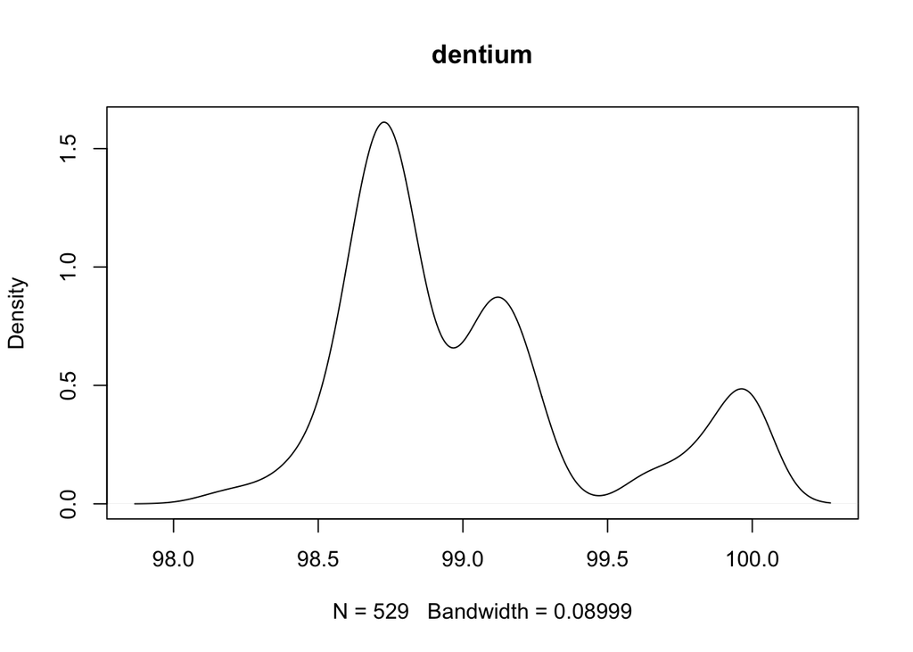

```
## [1] "stercoris"
```

```r
conter=0
for (i in colnames(matriz_stat_intra)){
  conter=conter+1
  lista_pos_matrix<-c()
  count=0
  for (y in colnames(matrix)) {
    count=count+1
    name<- strsplit(y," ")
    sp<- name[[1]][2]#Cogemos la especie
    if (i==sp){#esta condición para guardar las especies que sean iguales(intra-especie).
      lista_pos_matrix<-append(lista_pos_matrix,count)

    }
  }

  print(i)
  newmatrix<-matrix[lista_pos_matrix,lista_pos_matrix]
  valor<-CI_z(newmatrix)
  matriz_stat_intra[1,conter]<-valor$sample_size
  matriz_stat_intra[2,conter]<-valor$Mean
  matriz_stat_intra[3,conter]<-valor$sd
  CI_95<- as.character(paste(valor$CI_inferior,valor$CI_superior, sep = "-"))
  matriz_stat_intra[4,conter]<-CI_95
  matriz_stat_intra[5,conter]<-valor$Min
  if (i!="stercoris"){#Quitamos la especie estercolis porque solo tiene 1 dato daría error en el plot
    plot(density(newmatrix),main = i)
    #vioplot(newmatrix,xlab = i, ylab = "Valor_ANI")
  }
}
```

### PASO 1.2:

En segundo lugar, obtenemos las distribuciones de ANI INTER-especie y con ello vemos el intervalo de confianza para cada especie.El mecanismo es el mismo pero los valores de las filas se eliminarán por las que sean diferentes a la especie.

```r
conter=0
for (i in colnames(matriz_stat_inter)){
  conter=conter+1
  lista_pos_matrix<-c()
  count=0
  for (y in colnames(matrix)) {
    count=count+1
    name<- strsplit(y," ")
    sp<- name[[1]][2]#Cogemos la especie
    if (i==sp){#mantenemos esta condición pero después eliminamos las filas recogidas.
      lista_pos_matrix<-append(lista_pos_matrix,count)

    }
  }
  print(i)
  newmatrix<-matrix[(lista_pos_matrix)*-1,lista_pos_matrix]#Quitamos las filas iguales y nos quedamos con las no recogidas
  valor<-CI_z(newmatrix)
  matriz_stat_inter[1,conter]<-valor$sample_size
  matriz_stat_inter[2,conter]<-valor$Mean
  matriz_stat_inter[3,conter]<-valor$sd
  CI_95<- as.character(paste(valor$CI_inferior,valor$CI_superior, sep = "-"))
  matriz_stat_inter[4,conter]<-CI_95
  matriz_stat_inter[5,conter]<-valor$Min
  #plot(density(newmatrix),main = i)
}
```

```
## [1] "breve"
## [1] "kashiwanohense"
## [1] "animalis"
## [1] "bifidum"
## [1] "adolescentis"
## [1] "longum"
## [1] "pseudocatenulatum"
## [1] "pseudolongum"
## [1] "angulatum"
## [1] "catenulatum"
## [1] "dentium"
## [1] "stercoris"
```

### PASO 2:

Ahora observamos si los valores ANI intra e inter se acercan a los establecido en el artículo. Sacamos las medias de cada matriz.

```r
#Intra
library(kableExtra)
matriz_stat_intra %>% kbl()
```

|  | breve | kashiwanohense | animalis | bifidum | adolescentis | longum | pseudocatenulatum | pseudolongum | angulatum | catenulatum | dentium | stercoris |
| --- | --- | --- | --- | --- | --- | --- | --- | --- | --- | --- | --- | --- |
| Tamaño_N | 10000 | 16 | 1444 | 10609 | 7225 | 133956 | 4900 | 4 | 9 | 49 | 529 | 1 |
| Media_ANI_intra | 98.57230979 | 96.30961875 | 99.5965254155125 | 99.046505071166 | 98.2200111695502 | 97.8863959023859 | 98.4684790204082 | 98.965875 | 99.3672666666667 | 98.2156836734694 | 99.0134323251418 | 100 |
| Desviación | 0.38994752638078 | 2.40275951500735 | 1.19087404659022 | 0.235550747912854 | 0.363781996703003 | 2.5929838091784 | 0.424017013687142 | 1.19411936693951 | 0.74492078773518 | 1.34195121827431 | 0.453719946866089 | NA |
| CI 95% | 98.5646669589243-98.5799526210757 | 95.1322882217687-97.4869492782313 | 99.5351025144219-99.657948316603 | 99.042022828618-99.050987313714 | 98.2116229388236-98.2283994002768 | 97.872510233319-97.9002815714528 | 98.4566067621845-98.4803512786319 | 97.7956595237784-100.136090476222 | 98.8805940282346-99.8539393050987 | 97.8399442367798-98.591423110159 | 98.9747682053624-99.0520964449211 | NA-NA |
| Mínimo | 97.5446 | 93.9904 | 95.9479 | 98.5636 | 97.1478 | 70 | 96.729 | 97.9245 | 98.5603 | 96.0118 | 98.1359 | 100 |

```r
ANI_Intra<- matriz_stat_intra[2,]
mean(as.numeric(ANI_Intra))
```

```
## [1] 98.63851
```

```r
#Inter
matriz_stat_inter %>%
  kbl()
```

|  | breve | kashiwanohense | animalis | bifidum | adolescentis | longum | pseudocatenulatum | pseudolongum | angulatum | catenulatum | dentium | stercoris |
| --- | --- | --- | --- | --- | --- | --- | --- | --- | --- | --- | --- | --- |
| Tamaño_N | 70200 | 3192 | 29032 | 71997 | 60945 | 159576 | 51240 | 1600 | 2397 | 5565 | 17917 | 801 |
| media_ANI_inter | 83.1539458561254 | 81.1602380012531 | 77.5995984878755 | 80.1258903023737 | 80.5353655591107 | 81.4169048854464 | 80.1797202010148 | 78.111071375 | 79.9476516061744 | 80.9259952740341 | 79.5602602277167 | 82.3794923845194 |
| Desviación | 3.59984213097118 | 4.00000514961594 | 0.439252876332829 | 1.01355722807024 | 1.67847174240908 | 3.01841408148949 | 2.26376673750804 | 0.805044136379527 | 0.970270612490868 | 3.97448164907214 | 1.54177268927309 | 5.63498633240396 |
| CI 95% | 83.1273163574575-83.1805753547932 | 81.0214738766955-81.2990021258108 | 77.5945457795645-77.6046511961864 | 80.118486766827-80.1332938379204 | 80.5220397654435-80.5486913527779 | 81.4020952924931-81.4317144783998 | 80.1601193374889-80.1993210645408 | 78.0716249371683-78.1505178128317 | 79.9088091260937-79.986494086255 | 80.8215723132844-81.0304182347839 | 79.5376848101212-79.5828356453122 | 81.9892587489598-82.7697260200789 |
| Mínimo | 70 | 74.8066 | 70 | 70 | 70 | 70 | 70 | 70 | 70 | 70 | 70 | 74.7062 |

```r
ANI_Inter<- matriz_stat_inter[2,]
mean(as.numeric(ANI_Inter))
```

```
## [1] 80.42468
```

```r
dim(matrix)
```

```
## [1] 802 802
```

```r
matriz_stat_inter[,3]
```

```
##                            Tamaño_N                     media_ANI_inter
##                             "29032"                  "77.5995984878755"
##                          Desviación                              CI 95%
##                 "0.439252876332829" "77.5945457795645-77.6046511961864"
##                              Mínimo
##                                "70"
```

### PASO 3:

Realizamos una comparativa de distribuciones ANI de todos contra todos para poder unificar especies

Creamos la matriz de todos contra todos

```r
matriz_stat_Todos<-matrix(0,ncol = length(col_especies),nrow=length(col_especies))
colnames(matriz_stat_Todos)<-col_especies;rownames(matriz_stat_Todos)<-col_especies
```

Debido a que hay que recorrer 2 matrices y filas y columnas computacionalmente el coste es muy alto. Para evitar esto, extraeremos los índices de cada especie en la matriz

```r
lista_indices<-c()
lista_indices_pos_especie<-c()
count=0
for (nombre in colnames(matriz_stat_Todos)){
  for (i in 1:ncol(matrix)){
    b<-colnames(matrix)[i]
    name<- strsplit(b," ")
    sp<- name[[1]][2]#Cogemos la especie
    if (sp == nombre){
      count=count+1
      lista_indices<- append(lista_indices,i)
    }
  }
  lista_indices_pos_especie<-append(lista_indices_pos_especie,c(nombre,count))
}

lista_indices_pos_especie#Vemos la especie junto con su posición final dentro de la lista_indices(contiene los indices)
```

```
##  [1] "breve"             "100"               "kashiwanohense"
##  [4] "104"               "animalis"          "142"
##  [7] "bifidum"           "245"               "adolescentis"
## [10] "330"               "longum"            "696"
## [13] "pseudocatenulatum" "766"               "pseudolongum"
## [16] "768"               "angulatum"         "771"
## [19] "catenulatum"       "778"               "dentium"
## [22] "801"               "stercoris"         "802"
```

Se muestra la lista con la especie y el número acompañante es la posición de indices de cada especie en la lista de “lista_indices”.

Ahora que tenemos los indices de cada especie generamos la matriz de todos contra todos.

```r
pos_i=0
ini_fil=1
a_fil=2
for (i in row.names(matriz_stat_Todos)){
  pos_i=pos_i+1
  pos_y=0
  ini_col=1
  a_col=2

  for (y in colnames(matriz_stat_Todos)) {

    pos_y=pos_y+1
    newmatrix<-matrix[lista_indices[ini_fil:(as.numeric(lista_indices_pos_especie[a_fil]))],lista_indices[ini_col:(as.numeric(lista_indices_pos_especie[a_col]))]]
    matriz_stat_Todos[pos_i,pos_y]<-mean(newmatrix)
    ini_col=1+as.numeric(lista_indices_pos_especie[a_col])
    a_col=a_col+2
  }
  ini_fil=1+as.numeric(lista_indices_pos_especie[a_fil])
  a_fil=a_fil+2
}
```

Observamos las relaciones de cada especie con heatmap

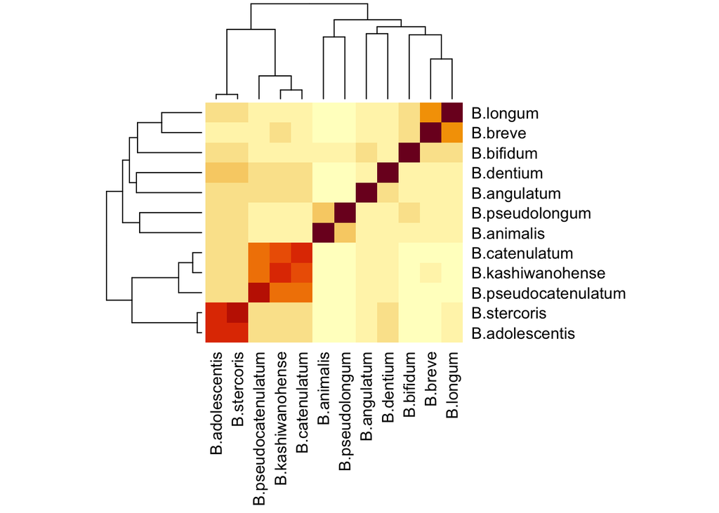

```r
#Generamos el heatmap
matriz_stat_Todos_heatmap<-matriz_stat_Todos
row.names(matriz_stat_Todos_heatmap)<- c("B.breve","B.kashiwanohense","B.animalis","B.bifidum","B.adolescentis","B.longum","B.pseudocatenulatum","B.pseudolongum","B.angulatum","B.catenulatum","B.dentium","B.stercoris")
colnames(matriz_stat_Todos_heatmap)<- c("B.breve","B.kashiwanohense","B.animalis","B.bifidum","B.adolescentis","B.longum","B.pseudocatenulatum","B.pseudolongum","B.angulatum","B.catenulatum","B.dentium","B.stercoris")
heatmap(matriz_stat_Todos_heatmap,margins =c(10,9) )
```

Ahora observamos que especies deben de unificarse atendiendo al valor de ANI. SI el valor de ANI >95% se deben unificar en la misma especie y sin ANI está >90 y <95 tienen proximidad filogenética

```r
for ( i in 1: nrow(matriz_stat_Todos)){
  for ( j in 1:ncol(matriz_stat_Todos)){
    if ((matriz_stat_Todos[i,j] > 95) & (i!=j)){
      print("LA especie:  ")
      print(row.names(matriz_stat_Todos)[i])
      print("se debería de unifcar con la especie  ")
      print(colnames(matriz_stat_Todos)[j])
      print(".................")
    }
    if ((matriz_stat_Todos[i,j] > 90) & (matriz_stat_Todos[i,j] < 95)){
      print("LA especie:  ")
      print(row.names(matriz_stat_Todos)[i])
      print("tiene mucha proximidad a   ")
      print(colnames(matriz_stat_Todos)[j])
      print("Valor de ANI:")
      print(matriz_stat_Todos[i,j])
      print(".................")
    }
  }
}
```

```
## [1] "LA especie:  "
## [1] "kashiwanohense"
## [1] "tiene mucha proximidad a   "
## [1] "pseudocatenulatum"
## [1] "Valor de ANI:"
## [1] 92.13709
## [1] "................."
## [1] "LA especie:  "
## [1] "kashiwanohense"
## [1] "tiene mucha proximidad a   "
## [1] "catenulatum"
## [1] "Valor de ANI:"
## [1] 94.91382
## [1] "................."
## [1] "LA especie:  "
```

[output cut: 37 more lines]

El resultado muestra que la especie estercolis se debe reunificar con adolescentis. Además, vemos como kashiwanohense y catenulatum tienen una ANI de casi 95 por lo que también las reunificaremos.

# Unir Especies

Para ello, creamos una función que recorra la matriz original en busca de los organismos que tengan un valor interespecie de <94

```r
fun_kill<- function(lista_1,lista_2){
  lista_rechazos<-c()
  for (i in lista_2[1]){
    i<-as.numeric(i)
    for (j in lista_2){
      j<-as.numeric(j)
      N<-matrix[i,j]
      if (lista_1[1]!="stercoris"){#Al estar solo esa especie da error, pero la quitamos porque más adelante la reunificaremos
        if (N< 93.89){#Uso un corte de 93.89 porque hay una kahawensis reunificada (antes era una "sp") que tiene 93.9 de ANI.
          lista_rechazos<-append(lista_rechazos,c(lista_1[1],j))
        }
      }
    }
  }
  return(lista_rechazos)
}

#Prueba de que funciona
#a=11
#prueba1<-lista_indices_pos_especie[a:(a+1)]
#prueba2<-lista_indices[331:696]
#i<-fun_kill(prueba1,prueba2)
#i
```

Ahora generamos un bucle que busque para todas las especies los organismos que no pertenecen a ella.

```r
lista_kill_end<-c()
a=1
pos=1
for (i in colnames(matriz_stat_intra)){
  lista_kill_end<-append(lista_kill_end,fun_kill(lista_indices_pos_especie[a:(a+1)],lista_indices[pos:(as.numeric(lista_indices_pos_especie[(a+1)]))]))
  print(pos)
  pos=1+as.numeric(lista_indices_pos_especie[a+1])
  a=a+2
}
```

```
## [1] 1
## [1] 101
## [1] 105
## [1] 143
## [1] 246
## [1] 331
## [1] 697
## [1] 767
## [1] 769
## [1] 772
## [1] 779
## [1] 802
```

```r
lista_kill_end
```

```
## [1] "longum" "482"    "longum" "483"
```

```r
colnames(matrix)[as.numeric(lista_kill_end[2])]
```

```
## [1] "\"Bifidobacterium longum strain 1173_BLON\""
```

```r
colnames(matrix)[as.numeric(lista_kill_end[4])]
```

```
## [1] "\"Bifidobacterium longum strain 981_BLON\""
```

Observamos que la posición 482 y 483 de la especie B.longum no pertenecen a dicha especie

## Unimos especies

Unimos las especies Stercolis con adolescentis y Kashiwanesis con Catenolatum.

B.kashiwanesis aparece en la bibliografia como una subespecie de B.catenulatum (https://www.ncbi.nlm.nih.gov/Taxonomy/Browser/wwwtax.cgi?mode=Info&id=1150460)por lo que cambiaremos el nombre de estas especies a catenulatum.

```r
lista_cambio<-c("kashiwanohense","stercoris")
#matrix_ZZ<-matrix
pos=1
a=1
for (i in 1:ncol(matriz_stat_inter)){
  if (lista_cambio[1]==lista_indices_pos_especie[pos]){#comprobar kashiwanohense
    print("entra")
    for (x in lista_indices[101:104]){#poner los indces de la especie kashiwanohense
      print("entra_1")
      fin_name<-paste("\"Bifidobacterium catenulatum "," _Antes_kashiwanohense\"",sep = "_")
      row.names(matrix)[x]<-paste(fin_name,a,sep = "_")
      colnames(matrix)[x]<-paste(fin_name,a,sep = "_")
      print(x)
      a=a+1
    }
  }
  if (lista_cambio[2]==lista_indices_pos_especie[pos]){
    print("Entra2")
    b=1
    fin_name<-paste("\"Bifidobacterium adolescentis "," _Antes_stercoris\"",sep = "_")
    row.names(matrix)[793]<-paste(fin_name,b,sep = "_")
    colnames(matrix)[793]<-paste(fin_name,b,sep = "_")

  }
  pos=pos+2
}
```

```
## [1] "entra"
## [1] "entra_1"
## [1] 3
## [1] "entra_1"
## [1] 38
## [1] "entra_1"
## [1] 478
## [1] "entra_1"
## [1] 479
## [1] "Entra2"
```

```r
#Comprobar que ha ido bien
#colnames(matrix)[4]
#colnames(matrix_ZZ)[4]
#colnames(matrix)[793]
#colnames(matrix_ZZ)[793]
```

Después de reunificar especies actualizamos la matriz eliminado las especies de B.longum

```r
matrix<-matrix[-c(482,483),-c(482,483)]
dim(matrix)
```

```
## [1] 800 800
```

## Comprobar que los cambios han modificado los valores intraespecies

Actualizamos las listas de especies a partir de la nueva matriz limpia

```r
##PASO 1: Generar listas con las especies filtradas
lista_especies=c()
lista_generos=c()
lista_posicion_especie=c()# Guardamos la lista con las posiciones encontradas para utilizarla después
count=0
for (i in colnames(matrix)) {####
  count=count+1
  name<- strsplit(i," ")

  yy<- name[[1]][1]#Cogemos el genero
  xx<- name[[1]][2]#Cogemos la especie
  if (!(yy %in% lista_generos)){
    lista_generos<- append(lista_generos,yy)
  }
  if ((yy== "\"Bifidobacterium") & (!(xx %in% lista_especies))){
    lista_especies<- append(lista_especies,xx)
    lista_posicion_especie<- append(lista_posicion_especie,count)
  }
}

print(lista_especies)
```

```
##  [1] "breve"             "catenulatum"       "animalis"
##  [4] "bifidum"           "adolescentis"      "longum"
##  [7] "pseudocatenulatum" "pseudolongum"      "angulatum"
## [10] "dentium"
```

```r
print(lista_generos)
```

```
## [1] "\"Bifidobacterium"
```

```r
##PASO 2: Volvemos a generar la matriz intraespecie

col_especies<- lista_especies
filas_stats<-c("Tamaño_N","media_ANI_intra","desviación","CI 95%","Minimo")
matriz_stat_intra<-matrix(0,ncol = length(col_especies),nrow=length(filas_stats))
colnames(matriz_stat_intra)<-col_especies;rownames(matriz_stat_intra)<- filas_stats
matriz_stat_inter<-matriz_stat_intra


##PASO 3.1: Rellenamos la matriz intra-especie

conter=0
for (i in colnames(matriz_stat_intra)){
  conter=conter+1
  lista_pos_matrix<-c()
  count=0
  for (y in colnames(matrix)) {#####
    count=count+1
    name<- strsplit(y," ")
    sp<- name[[1]][2]#Cogemos la especie
    if (i==sp){#esta condición para guardar las especies que sean iguales(intra-especie).
      lista_pos_matrix<-append(lista_pos_matrix,count)

    }
  }

  print(i)
  newmatrix<-matrix[lista_pos_matrix,lista_pos_matrix]####
  valor<-CI_z(newmatrix)
  matriz_stat_intra[1,conter]<-valor$sample_size
  matriz_stat_intra[2,conter]<-valor$Mean
  matriz_stat_intra[3,conter]<-valor$sd
  CI_95<- as.character(paste(valor$CI_inferior,valor$CI_superior, sep = "-"))
  matriz_stat_intra[4,conter]<-CI_95
  matriz_stat_intra[5,conter]<-valor$Min
  #plot(density(newmatrix),main = i)
}
```

```
## [1] "breve"
## [1] "catenulatum"
## [1] "animalis"
## [1] "bifidum"
## [1] "adolescentis"
## [1] "longum"
## [1] "pseudocatenulatum"
## [1] "pseudolongum"
## [1] "angulatum"
## [1] "dentium"
```

```r
##PASO 3.2: Rellenamos la matriz inter-especie
conter=0
for (i in colnames(matriz_stat_inter)){
  conter=conter+1
  lista_pos_matrix<-c()
  count=0
  for (y in colnames(matrix)) {
    count=count+1
    name<- strsplit(y," ")
    sp<- name[[1]][2]#Cogemos la especie
    if (i==sp){#mantenemos esta condición pero después eliminamos las filas recogidas.
      lista_pos_matrix<-append(lista_pos_matrix,count)

    }
  }
  print(i)
  newmatrix<-matrix[(lista_pos_matrix)*-1,lista_pos_matrix]#Quitamos las filas iguales y nos quedamos con las no recogidas
  valor<-CI_z(newmatrix)
  matriz_stat_inter[1,conter]<-valor$sample_size
  matriz_stat_inter[2,conter]<-valor$Mean
  matriz_stat_inter[3,conter]<-valor$sd
  CI_95<- as.character(paste(valor$CI_inferior,valor$CI_superior, sep = "-"))
  matriz_stat_inter[4,conter]<-CI_95
  matriz_stat_inter[5,conter]<-valor$Min
  #plot(density(newmatrix),main = i)
}
```

```
## [1] "breve"
## [1] "catenulatum"
## [1] "animalis"
## [1] "bifidum"
## [1] "adolescentis"
## [1] "longum"
## [1] "pseudocatenulatum"
## [1] "pseudolongum"
## [1] "angulatum"
## [1] "dentium"
```

```r
#PASO 4.1: Generamos la matriz todos contra todos
matriz_stat_Todos<-matrix(0,ncol = length(col_especies),nrow=length(col_especies))
colnames(matriz_stat_Todos)<-col_especies;rownames(matriz_stat_Todos)<-col_especies

#PASO 4.2: Generamos la listas con los nuevos indices
lista_indices<-c()
lista_indices_pos_especie<-c()
count=0
for (nombre in colnames(matriz_stat_Todos)){
  for (i in 1:ncol(matrix)){
    b<-colnames(matrix)[i]
    name<- strsplit(b," ")
    sp<- name[[1]][2]#Cogemos la especie
    if (sp == nombre){
      count=count+1
      lista_indices<- append(lista_indices,i)
    }
  }
  lista_indices_pos_especie<-append(lista_indices_pos_especie,c(nombre,count))
}

lista_indices_pos_especie#Vemos la especie junt
```

```
##  [1] "breve"             "100"               "catenulatum"
##  [4] "111"               "animalis"          "149"
##  [7] "bifidum"           "252"               "adolescentis"
## [10] "338"               "longum"            "702"
## [13] "pseudocatenulatum" "772"               "pseudolongum"
## [16] "774"               "angulatum"         "777"
## [19] "dentium"           "800"
```

```r
#PASO 4.3: Eellenamos la matriz todos contra todos (matriz_stat_Todos)

pos_i=0
ini_fil=1
a_fil=2
for (i in row.names(matriz_stat_Todos)){
  pos_i=pos_i+1
  pos_y=0
  ini_col=1
  a_col=2

  for (y in colnames(matriz_stat_Todos)) {

    pos_y=pos_y+1
    newmatrix<-matrix[lista_indices[ini_fil:(as.numeric(lista_indices_pos_especie[a_fil]))],lista_indices[ini_col:(as.numeric(lista_indices_pos_especie[a_col]))]]
    matriz_stat_Todos[pos_i,pos_y]<-mean(newmatrix)
    ini_col=1+as.numeric(lista_indices_pos_especie[a_col])
    a_col=a_col+2
  }
  ini_fil=1+as.numeric(lista_indices_pos_especie[a_fil])
  a_fil=a_fil+2
}

#Se muestra la tabla intraespecie final
matriz_stat_intra %>% kbl()
```

|  | breve | catenulatum | animalis | bifidum | adolescentis | longum | pseudocatenulatum | pseudolongum | angulatum | dentium |
| --- | --- | --- | --- | --- | --- | --- | --- | --- | --- | --- |
| Tamaño_N | 10000 | 121 | 1444 | 10609 | 7396 | 132496 | 4900 | 4 | 9 | 529 |
| media_ANI_intra | 98.57230979 | 96.4384438016529 | 99.5965254155125 | 99.046505071166 | 98.2198241211466 | 98.1220509230467 | 98.4684790204082 | 98.965875 | 99.3672666666667 | 99.0134323251418 |
| desviación | 0.38994752638078 | 2.10012469050025 | 1.19087404659022 | 0.235550747912854 | 0.36175058519653 | 1.18667290775753 | 0.424017013687142 | 1.19411936693951 | 0.74492078773518 | 0.453719946866089 |
| CI 95% | 98.5646669589243-98.5799526210757 | 96.064246641978-96.8126409613278 | 99.5351025144219-99.657948316603 | 99.042022828618-99.050987313714 | 98.2115797244213-98.2280685178718 | 98.1156612632648-98.1284405828287 | 98.4566067621845-98.4803512786319 | 97.7956595237784-100.136090476222 | 98.8805940282346-99.8539393050987 | 98.9747682053624-99.0520964449211 |
| Minimo | 97.5446 | 93.8622 | 95.9479 | 98.5636 | 97.1478 | 93.8079 | 96.729 | 97.9245 | 98.5603 | 98.1359 |

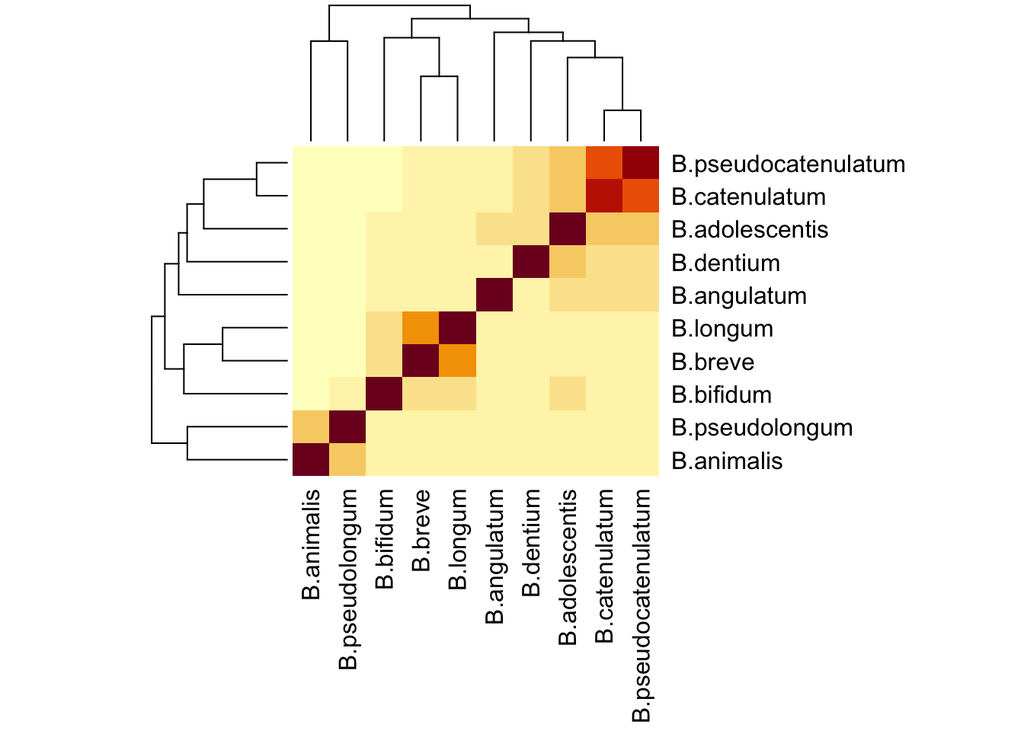

```r
#PASO 5: Mostramos la relación de la matriz todos contra todos con un heatmap

matriz_stat_Todos_heatmap<-matriz_stat_Todos
row.names(matriz_stat_Todos_heatmap)<- c("B.breve","B.catenulatum","B.animalis","B.bifidum","B.adolescentis","B.longum","B.pseudocatenulatum","B.pseudolongum","B.angulatum","B.dentium")
colnames(matriz_stat_Todos_heatmap)<- c("B.breve","B.catenulatum","B.animalis","B.bifidum","B.adolescentis","B.longum","B.pseudocatenulatum","B.pseudolongum","B.angulatum","B.dentium")
heatmap(matriz_stat_Todos_heatmap,margins =c(10.5,9) )
```

## Generamos un data frame con los valores interespecies para poder representar un violinplot

Para el data frame generamos unas listas con cada valor de ANI intra-especie

```r
#generar violin plot
breve<-c()
bifidum<-c()
animalis<-c()
catenulatum<-c()
adolescentis<-c()
longum<-c()
pseudocatenulatum<-c()
pseudolongum<-c()
angulatum<-c()
dentium<-c()

lista_indices_pos_especie
```

```
##  [1] "breve"             "100"               "catenulatum"
##  [4] "111"               "animalis"          "149"
##  [7] "bifidum"           "252"               "adolescentis"
## [10] "338"               "longum"            "702"
## [13] "pseudocatenulatum" "772"               "pseudolongum"
## [16] "774"               "angulatum"         "777"
## [19] "dentium"           "800"
```

```r
pos=0
for (i in lista_indices){
  pos=pos+1
  if (pos<=100){
    breve<-append(breve,matrix[lista_posicion_especie[1],i])#Una es la posición de breve
  }
  if ((pos>100)&(pos<=111)){
    catenulatum<-append(catenulatum,matrix[lista_posicion_especie[2],i])#Una es la posición de catenulatum
  }
  if ((pos>111)&(pos<=149)){
    animalis<-append(animalis,matrix[lista_posicion_especie[3],i])#Una es la posición de catenulatum
  }
  if ((pos>149)&(pos<=252)){
    bifidum<-append(bifidum,matrix[lista_posicion_especie[4],i])#Una es la posición de catenulatum
  }
  if ((pos>252)&(pos<=338)){
    adolescentis<-append(adolescentis,matrix[lista_posicion_especie[5],i])#Una es la posición de breve
  }
  if ((pos>338)&(pos<=702)){
    longum<-append(longum,matrix[lista_posicion_especie[6],i])#Una es la posición de catenulatum
  }
  if ((pos>702)&(pos<=772)){
    pseudocatenulatum<-append(pseudocatenulatum,matrix[lista_posicion_especie[7],i])#Una es la posición de catenulatum
  }
  if ((pos>772)&(pos<=774)){
    pseudolongum<-append(pseudolongum,matrix[lista_posicion_especie[8],i])#Una es la posición de catenulatum
  }
  if ((pos>774)&(pos<=777)){
    angulatum<-append(angulatum,matrix[lista_posicion_especie[9],i])#Una es la posición de catenulatum
  }
  if ((pos>777)&(pos<=800)){
    dentium<-append(dentium,matrix[lista_posicion_especie[10],i])#Una es la posición de catenulatum
  }
}
```

## Generar el violinplot

```r
#df_violin<-data_frame(breve,catenulatum,animalis,bifidum,adolescentis,longum,pseudocatenulatum,pseudolongum,angulatum,dentium)

# PASO 1: EXTRAEMOS LA LONGITUD
max_length <- max(c(length(breve), length(catenulatum),length(animalis), length(bifidum),length(adolescentis), length(longum),length(pseudocatenulatum), length(pseudolongum),length(angulatum), length(dentium)))
max_length
```

```
## [1] 364
```

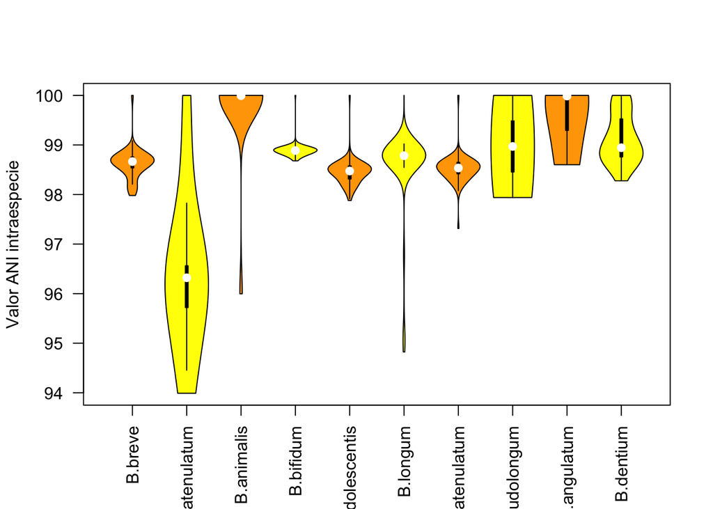

```r
df_puebar <- data.frame(breve = c(breve,                 # Create data frame with unequal vectors
                            rep(NA, max_length - length(breve))),
                   catenulatum = c(catenulatum,
                            rep(NA, max_length - length(catenulatum))))
#t()
l<-list(breve,catenulatum,animalis,bifidum,adolescentis,longum,pseudocatenulatum,pseudolongum,angulatum,dentium)
vioplot::vioplot(l,names=c("B.breve","B.catenulatum","B.animalis","B.bifidum","B.adolescentis","B.longum","B.pseudocatenulatum","B.pseudolongum","B.angulatum","B.dentium"),col=c("orange","yellow"),ylab="Valor ANI intraespecie",las=2.1, cex.lab=1, cex.axis=1, font=1,col.axis="black",bandwidth = 0.2, adjust = 2)
```